# Income Inequality vs Index of Health and Social Problems

coop711

2025-05-07

### Data

Equality Trust에서 기부금을 받고 제공하는 두 종류의 자료 중 23개 국가의 각종 지표를 비교한 자료에 World Bank에서 발표하는 GDP자료를 추가하여 읽어들이면,

```r
library(knitr)
library(RColorBrewer)
# load("Inequality_Index_HS.rda")
# data.full <- read.csv("../data/international-inequality_GDP.csv",
#                      stringsAsFactors = FALSE)
# rm(list = ls())
# getwd()
load("Inequality_Index_HS.RData")
data.full <- read.csv("../data/international-inequality_GDP.csv",
                      stringsAsFactors = FALSE)
str(data.full)
```

```
## 'data.frame':    23 obs. of  30 variables:
##  $ Country                          : chr  "Australia" "Austria" "Belgium" "Canada" ...
##  $ Income.inequality                : num  7 4.82 4.6 5.63 4.3 3.72 5.6 5.2 6.2 6.05 ...
##  $ Trust                            : num  39.9 33.9 30.7 38.8 66.5 58 22.2 34.8 23.7 35.2 ...
##  $ Life.expectancy                  : num  79.2 78.5 78.8 79.3 76.6 78 79 78.3 78.3 77 ...
##  $ Infant.mortality                 : num  4.9 4.8 5 5.3 5.3 3.7 4.4 4.4 5 5.9 ...
##  $ Obesity                          : num  18.4 14.5 13.5 12.8 15 ...
##  $ Mental.illness                   : num  23 NA 12 19.9 NA NA 18.4 9.1 NA NA ...
##  $ Maths.and.literacy.scores        : num  524 498 518 530 503 ...
##  $ Teenage.births                   : num  18.4 14 9.9 20.2 8.1 9.2 9.3 13.1 11.8 18.7 ...
##  $ Homicides                        : num  16.9 11.6 13 17.3 12.7 28.2 21.5 13.7 13.9 8.6 ...
##  $ Imprisonment..log.               : num  4.61 4.52 4.28 4.77 4.17 4.11 4.5 4.51 3.33 4.17 ...
##  $ Social.mobility                  : num  NA NA NA 0.14 0.14 0.15 NA 0.17 NA NA ...
##  $ Index.of.health...social_problems: num  0.07 0.01 -0.23 -0.07 -0.19 -0.43 0.05 -0.06 0.38 0.25 ...
##  $ Child.overweight                 : num  NA 11.9 10.4 19.5 10.3 13.3 11.2 11.3 16 12.1 ...
```

[output cut: 16 more lines]

## 소득불평등

이 자료 중 소득불평등을 나타내는 지표는 5분위계수로서 두번째 컬럼에 `Income.inequality`라는 이름으로 나와 있고, 건강과 사회문제 지표는 13번째 컬럼에 `Index.of.health...social_problems`라는 이름으로 주어져 있다. 나라들은 `Country`라는 변수명으로 첫번째 컬럼에 나와 있다.

### Barplot(geom_bar)

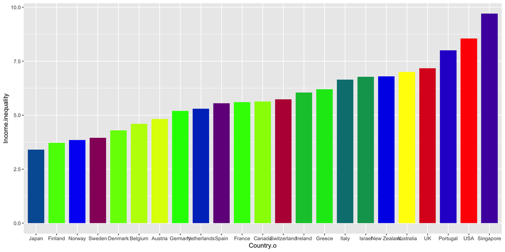

```r
# par(mai = c(2.0, 0.8, 0.8, 0.4) + 0.02)
library(ggplot2)
source("theme_kr.R")
# colfunc <- colorRampPalette(brewer.pal(9, "YlOrRd"))
# colfunc <- colorRampPalette(brewer.pal(11, "RdYlGn"))
colfunc <- colorRampPalette(c("Yellow", "Green", "Blue", "Red"))
fill.col <- colfunc(23)
o.ineq <- order(data.full$Income.inequality)
fifth_ratio <- data.full$Income.inequality
Country <- data.full$Country
data.full$Country.o <- factor(Country, levels = Country[o.ineq])
g1 <- ggplot(data = data.full[c("Income.inequality", "Country.o")])
g2 <- g1 +
  geom_bar(mapping = aes(x = Country.o, y = Income.inequality),
           stat = "identity",
           width = 0.8,
           fill = fill.col)
#           fill = rev(rainbow(23, start = 0, end = 2/3)))

g2
```

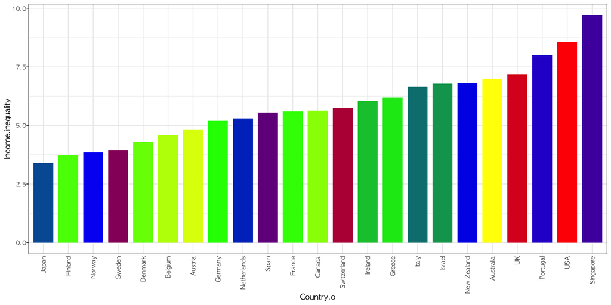

```r
g3 <- g2 +
  theme_bw()
g4 <- g3 +
#  theme(axis.text.x = element_blank()) +
  theme(axis.ticks.x = element_blank()) +
  theme(axis.text.x = element_text(angle = 90,
                                   hjust = 1,
                                   vjust = 0.5)) +
  theme.kr
g4
```

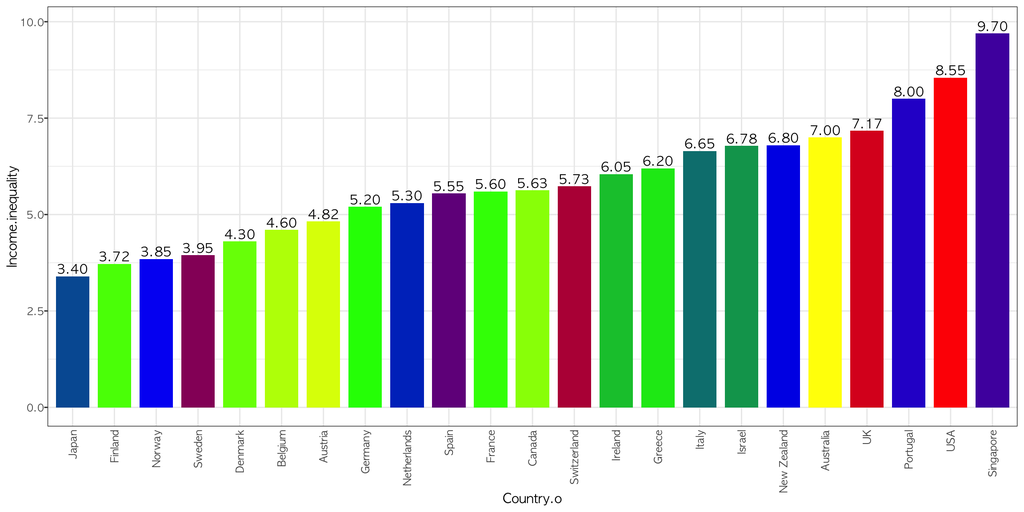

```r
g5 <- g4 +
  geom_text(aes(x = Country.o,
                y = Income.inequality + 0.2,
                label = format(Income.inequality,
                               digits = 3,
                               nsmall = 2)),
            family = "AppleGothic")
g5
```

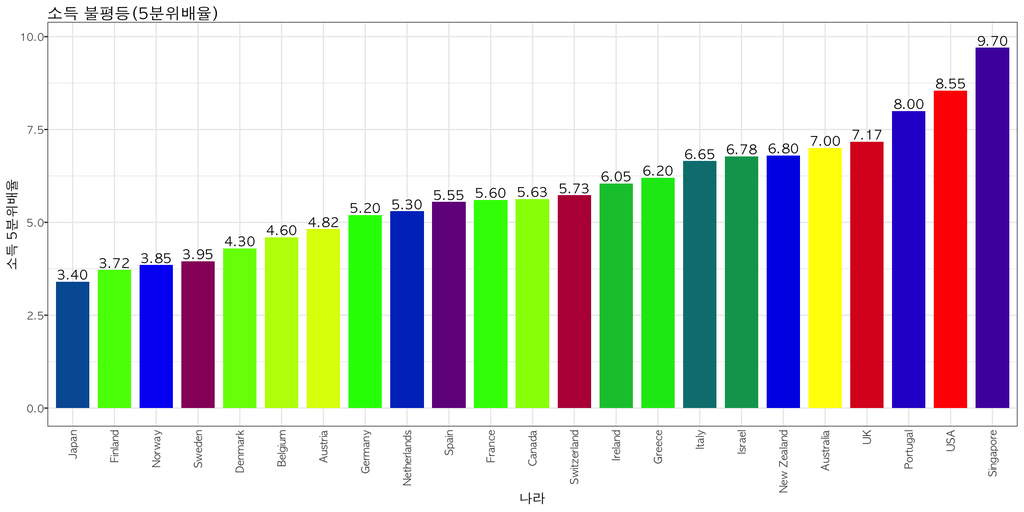

```r
g6 <- g5 +
  labs(title = "소득 불평등(5분위배율)",
       x = "나라",
       y = "소득 5분위배율")
g6
```

```r
ggsave("../pics/Fifth_Ratio_ggplot.png",
       g6,
       width = 12,
       height = 6)
```

## 소득불평등과 건강 및 사회문제

### data management

그리고, 건강과 사회문제 지표에 결측치들이 있기 때문에 먼저 이 나라들을 제외하고 분석작업을 수행하여야 한다. `which()`를 이용하여 해당 인덱스를 찾고, 나라명을 추출한다.

```r
(country.na <- which(is.na(data.full$Index.of.health...social_problems)))
```

```
## [1] 11 18
```

```r
data.full$Country[country.na]
```

```
## [1] "Israel"    "Singapore"
```

결측치가 있는 나라를 빼고, 필요한 변수만 챙겨서 새로운 data frame 을 구성하기 위하여 건강과 사회문제 지표의 위치를 찾아보자.

```r
names(data.full)
```

```
##  [1] "Country"                           "Income.inequality"
##  [3] "Trust"                             "Life.expectancy"
##  [5] "Infant.mortality"                  "Obesity"
##  [7] "Mental.illness"                    "Maths.and.literacy.scores"
##  [9] "Teenage.births"                    "Homicides"
## [11] "Imprisonment..log."                "Social.mobility"
## [13] "Index.of.health...social_problems" "Child.overweight"
## [15] "Drugs.index"                       "Calorie.intake"
## [17] "Public.health.expenditure"         "Child.wellbeing"
## [19] "Maths.education.science.score"     "Child.conflict"
## [21] "Foreign.aid"                       "Recycling"
## [23] "Peace.index"                       "Maternity.leave"
## [25] "Advertising"                       "Police"
## [27] "Social.expenditure"                "Women.s_status"
## [29] "Lone.parents"                      "GDP_WB"
## [31] "Country.o"
```

```r
which(names(data.full) == "Index.of.health...social_problems")
```

```
## [1] 13
```

새로운 data frame 을 `data.21` 으로 저장하자. 시각적 가독성을 높이기 위하여 자릿수를 조정한다.

```r
options(digits = 2)
v.names <- c("Country",
             "Income.inequality",
             "Index.of.health...social_problems",
             "GDP_WB")
data.21 <- data.full[-c(11, 18), v.names]
names(data.21)[3] <- "Index.HS"
kable(data.21)
```

|  | Country | Income.inequality | Index.HS | GDP_WB |
| --- | --- | --- | --- | --- |
| 1 | Australia | 7.0 | 0.07 | 45926 |
| 2 | Austria | 4.8 | 0.01 | 47682 |
| 3 | Belgium | 4.6 | -0.23 | 43435 |
| 4 | Canada | 5.6 | -0.07 | 45066 |
| 5 | Denmark | 4.3 | -0.19 | 45537 |
| 6 | Finland | 3.7 | -0.43 | 40676 |
| 7 | France | 5.6 | 0.05 | 39328 |
| 8 | Germany | 5.2 | -0.06 | 46401 |
| 9 | Greece | 6.2 | 0.38 | 26851 |
| 10 | Ireland | 6.0 | 0.25 | 49393 |
| 12 | Italy | 6.7 | -0.12 | 35463 |
| 13 | Japan | 3.4 | -1.26 | 36319 |
| 14 | Netherlands | 5.3 | -0.51 | 48253 |
| 15 | New Zealand | 6.8 | 0.29 | 37679 |
| 16 | Norway | 3.9 | -0.63 | 65615 |
| 17 | Portugal | 8.0 | 1.18 | 28760 |
| 19 | Spain | 5.5 | -0.30 | 33629 |
| 20 | Sweden | 4.0 | -0.83 | 45297 |
| 21 | Switzerland | 5.7 | -0.46 | 59540 |
| 22 | UK | 7.2 | 0.79 | 40233 |
| 23 | USA | 8.6 | 2.02 | 54630 |

### Plots

우선 소득불평등과 건강 및 사회문제 지표의 관계를 대략적으로 살펴보면,

```r
library(extrafont)
```

```r
Country.kr <- c("호주", "오스트리아", "벨기에", "캐나다", "덴마크",
"핀란드", "프랑스", "독일", "그리스", "아일랜드", "이탈리아",
"일본", "네덜란드", "뉴질랜드", "노르웨이", "포르투갈",
"스페인", "스웨덴", "스위스", "영국", "미국")
Index_inequality.df <- data.21[c("Country",
                                 "Income.inequality",
                                 "Index.HS")]
# plot(Index_inequality.df)
# plot(data.21[c("Income.inequality", "Index.HS")])
cor.1 <- cor(data.21["Income.inequality"], data.21["Index.HS"])
cor.1
```

```
##                   Index.HS
## Income.inequality     0.87
```

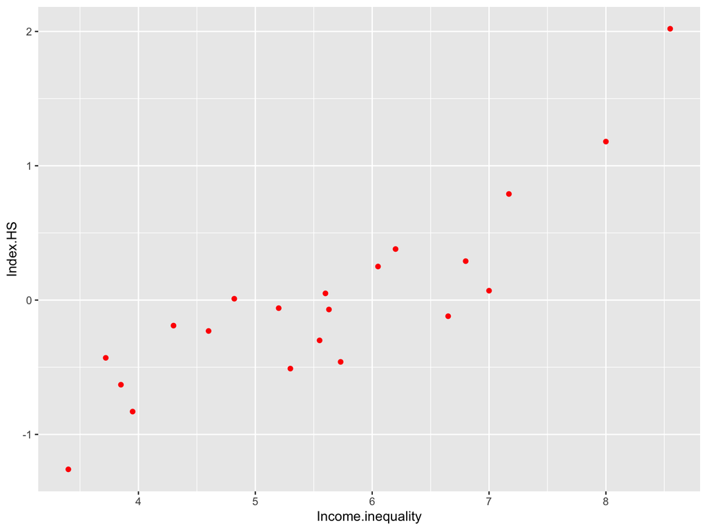

```r
p1 <- ggplot(data = Index_inequality.df,
             mapping = aes(x = Income.inequality,
                           y = Index.HS,
                           label = Country.kr))
p1.1 <- p1 +
  geom_point(col = "red")
p1.1
```

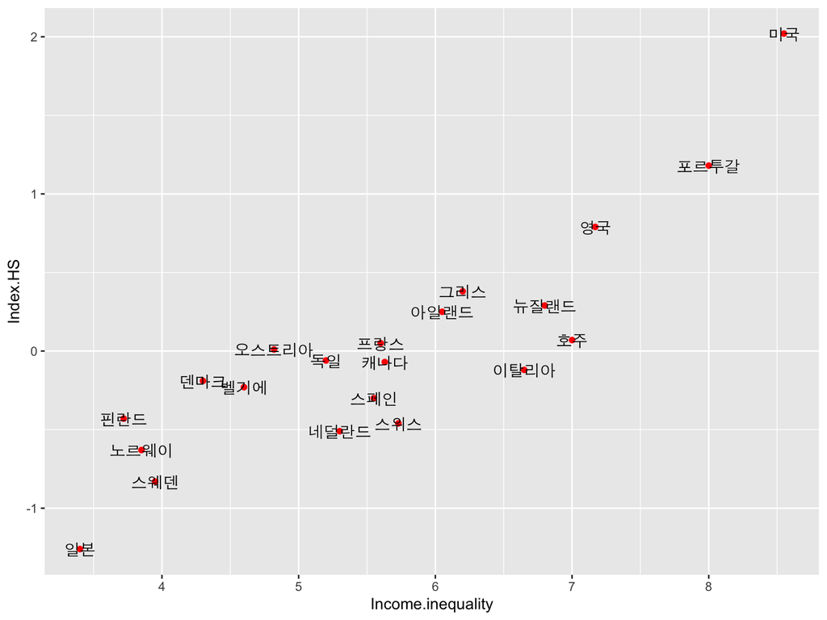

```r
p1.2 <- p1.1 +
  geom_text(family = "AppleGothic")
p1.2
```

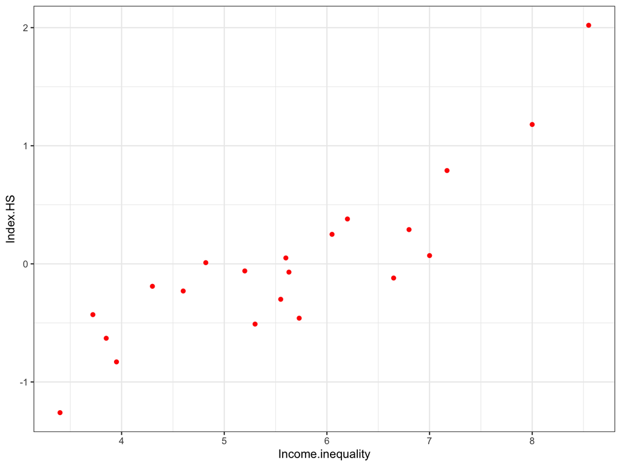

```r
p2 <- p1.1 +
  theme_bw()
#  theme.kr
p2
```

텍스트 위치를 옮겨 보자. 점의 왼편으로 옮겨야 할 나라들(`ggplot`에서는 `hjust = "right"`)을 먼저 찾아보자.

```r
Country <- data.21$Country
which(Country %in% c("Austria", "Denmark", "Germany", "Netherlands"))
```

```
## [1]  2  5  8 13
```

```r
text.left <- which(Country %in% c("Austria", "Denmark", "Germany", "Netherlands"))
text.left
```

```
## [1]  2  5  8 13
```

```r
text.right <- setdiff(1:nrow(data.21), text.left)
text.right
```

```
##  [1]  1  3  4  6  7  9 10 11 12 14 15 16 17 18 19 20 21
```

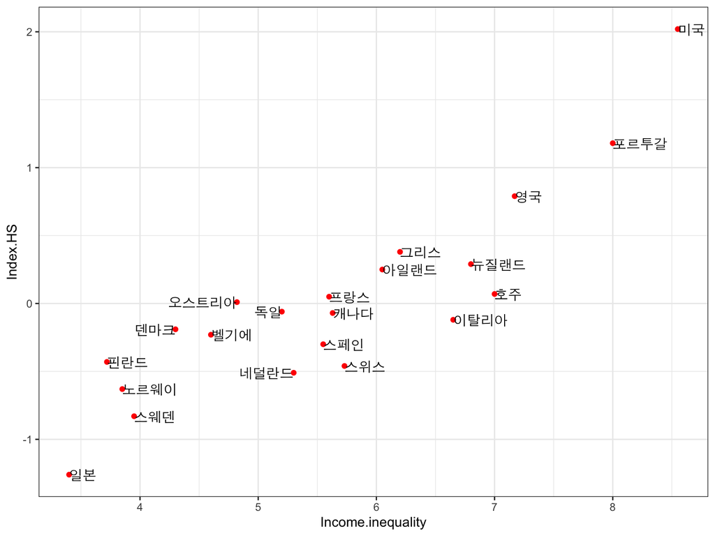

```r
hjust.text <- ifelse(1:nrow(data.21) %in% text.left, "right", "left")
p4 <- p2 +
  geom_text(hjust = hjust.text,
  family = "AppleGothic")
p4
```

독일의 라벨을 위로 붙이면 보기가 나아질 것으로 생각되므로,

```r
which(Country %in% "Germany")
```

```
## [1] 8
```

```r
text.up <- which(Country %in% "Germany")
text.up
```

```
## [1] 8
```

```r
text.left <- setdiff(1:nrow(data.21), c(text.right, text.up))
text.left
```

```
## [1]  2  5 13
```

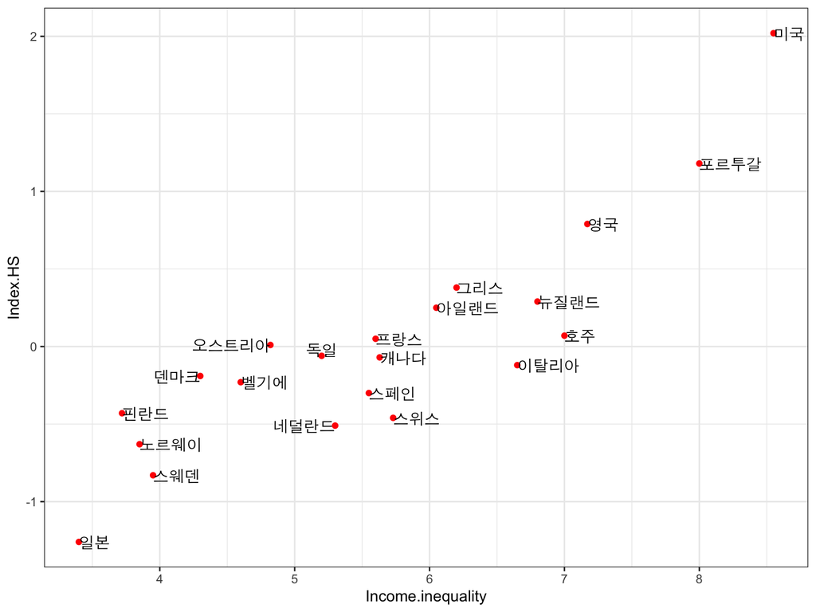

```r
vjust.text <- ifelse(1:nrow(data.21) %in% text.up, "bottom", "center")
hjust.text <- ifelse(1:nrow(data.21) %in% text.up, "middle", hjust.text)
p5 <- p2 +
  geom_text(hjust = hjust.text,
            vjust = vjust.text,
            family = "AppleGothic")
p5
```

세부조정을 위해서 `nudge_x, nudge_y` 설정

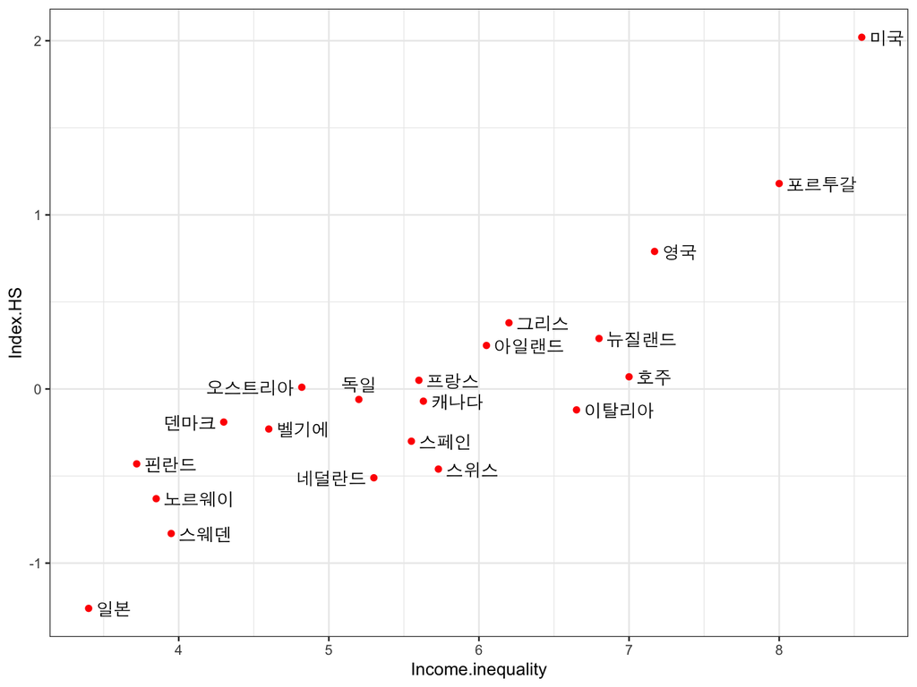

```r
nudge_y.text <- ifelse(vjust.text == "bottom", 0.05, 0)
nudge_x.text <- ifelse(hjust.text == "middle", 0, ifelse(hjust.text == "right", -0.05, 0.05))
p6 <- p2 +
  geom_text(hjust = hjust.text,
            vjust = vjust.text,
            nudge_x = nudge_x.text,
            nudge_y = nudge_y.text,
            family = "AppleGothic")
p6
```

건강 및 사회문제 지표의 경우 어느 방향이 좋은지 알 수 없으므로 친절하게 도표의 주변에(margin)에 알려주고, 이제 조정된 text 외에 x-축과 y-축에 적절한 라벨과 메인 타이틀을 넣어보자.

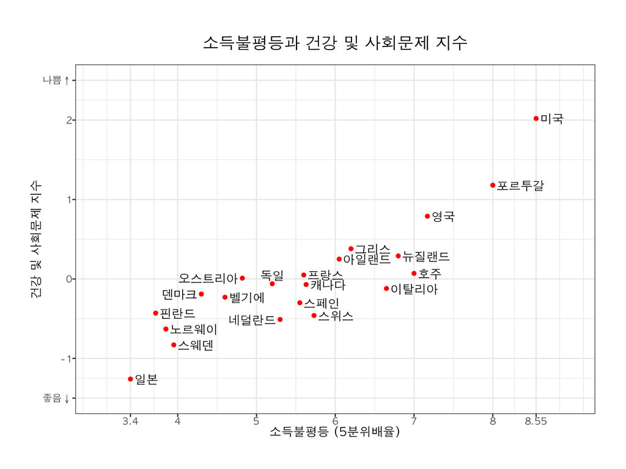

```r
main.title <- "소득불평등과 건강 및 사회문제 지수\n"
x.lab <- "소득불평등 (5분위배율)"
y.lab <- "건강 및 사회문제 지수"
lowest <- data.21$Income.inequality[Country == "Japan"]
highest <- data.21$Income.inequality[Country == "USA"]
p7 <- p6 + theme.kr +
  scale_x_continuous(name = x.lab,
                     breaks = c(lowest, 4:8, highest),
                     labels = c(lowest, 4:8, highest),
                     limits = c(3, 9)) +
  scale_y_continuous(name = y.lab,
                     breaks = c(-1.5, -1:2, 2.5),
                     labels = c(expression("좋음" %down% ""),
                                -1:2,
                                expression("나쁨" %up% "")),
                     limits = c(-1.5, 2.5)) +
  labs(title = main.title) +
  theme(plot.title = element_text(hjust = 0.5, vjust = -0.5, size = 15,
                                  family = "AppleGothic"),
        plot.margin = margin(1, 1, 1, 1, "cm"),
        )
p7
```

상관계수를 텍스트로 그림 안에 넣어주고 여기까지 작업한 내용을 별도의 파일로 저장해 놓으려면,

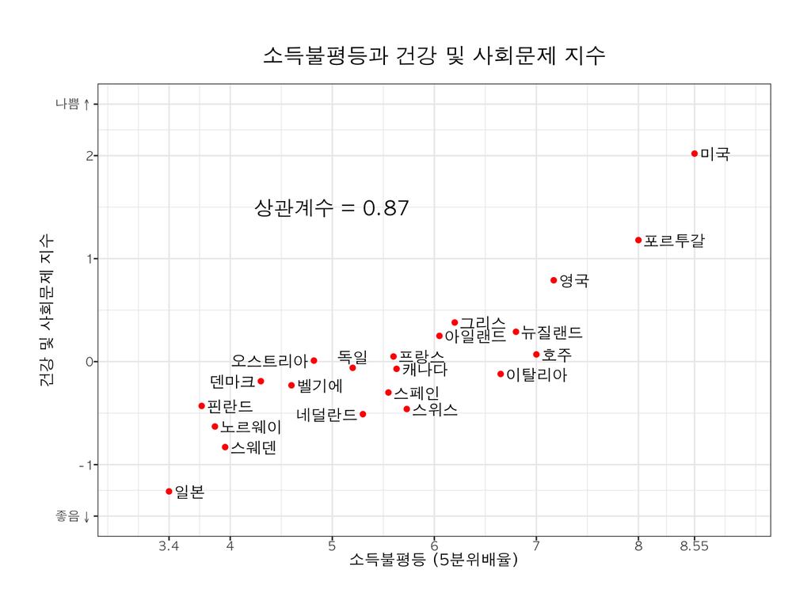

```r
p8 <- p7 +
  annotate("text",
           x = 5,
           y = 1.5,
           label = paste("상관계수 =", round(cor.1, digits = 2)),
           size = 5,
           family = "AppleGothic")
p8
```

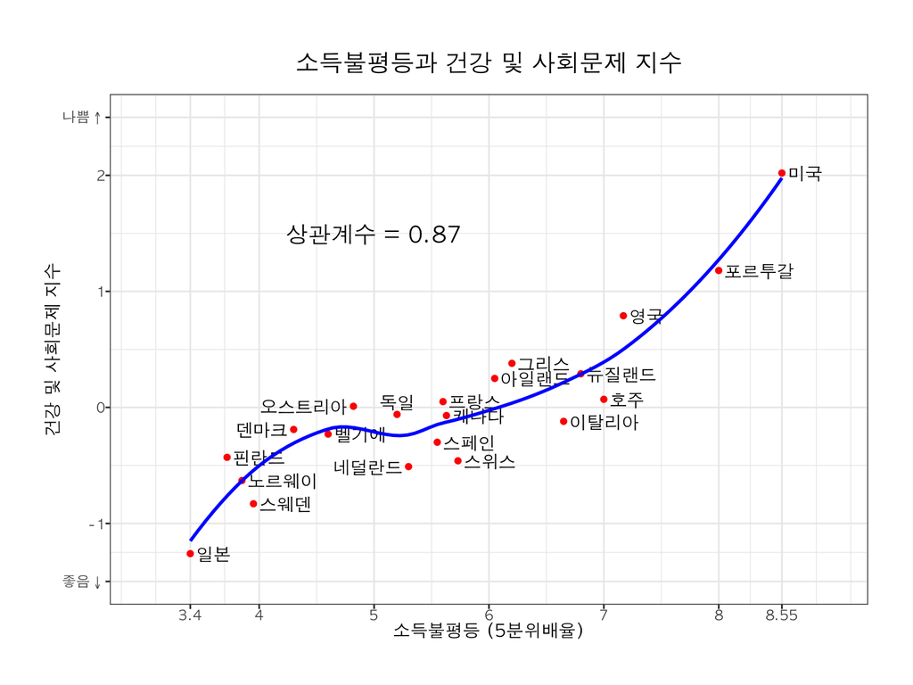

```r
lm.ineq <- lm(Index.HS ~ Income.inequality, data = Index_inequality.df)
# lm.ineq <- lm(Index_inequality.df[2:1])
# p9 <- p8 + geom_abline(intercept = lm.ineq$coef[1], slope = lm.ineq$coef[2], colour = "blue")
p9 <- p8 +
  geom_smooth(method = "loess",
              se = FALSE,
              colour = "blue",
              inherit.aes = FALSE,
              mapping = aes(x = Income.inequality, y = Index.HS))
p9.2 <- p8 +
  geom_smooth(method = "loess",
              se = TRUE,
              colour = "blue",
              inherit.aes = FALSE,
              mapping = aes(x = Income.inequality, y = Index.HS))
p9
```

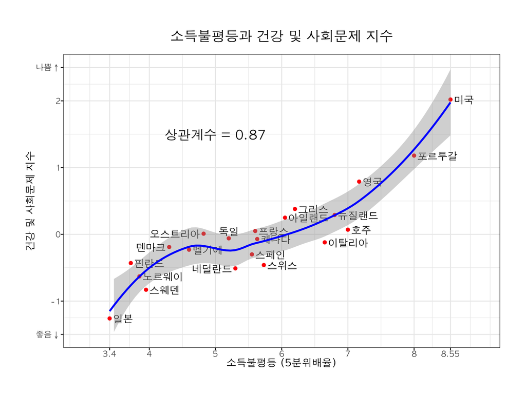

```r
p9.2
```

```r
ggsave("../pics/Inequality_vs_HS_Index_ggplot.png",
       p9,
       dpi = 300)
ggsave("../pics/Inequality_vs_HS_Index_ggplot_se.png",
       p9.2,
       dpi = 300)
```

[output not shown]

[output not shown]

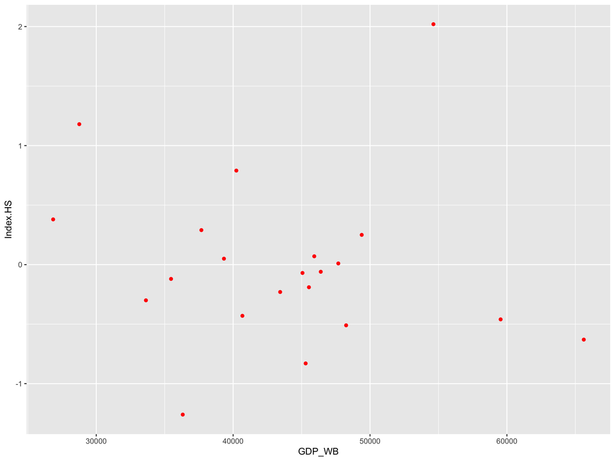

```r
cor.2 <- cor(data.21["GDP_WB"], data.21["Index.HS"])
text.left.2 <- which(Country %in% c("Australia", "Belgium", "Canada", "France"))
text.right.2 <- setdiff(1:nrow(data.21), c(text.left.2))
hjust.text.2 <- ifelse(1:nrow(data.21) %in% text.left.2, "right", "left")
nudge_x.text.2 <- ifelse(hjust.text.2 == "right", -250, 250)
gd1 <- ggplot(data = Index_GDP.df,
              mapping = aes(x = GDP_WB,
                            y = Index.HS,
                            label = Country))
gd1.1 <- gd1 +
  geom_point(colour = "red")
gd1.1
```

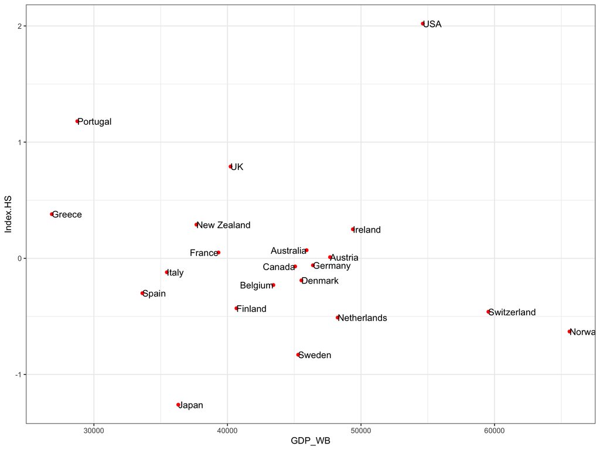

```r
gd2 <- gd1.1 +
  theme_bw()
gd3 <- gd2 +
  geom_text(hjust = hjust.text.2)
gd3
```

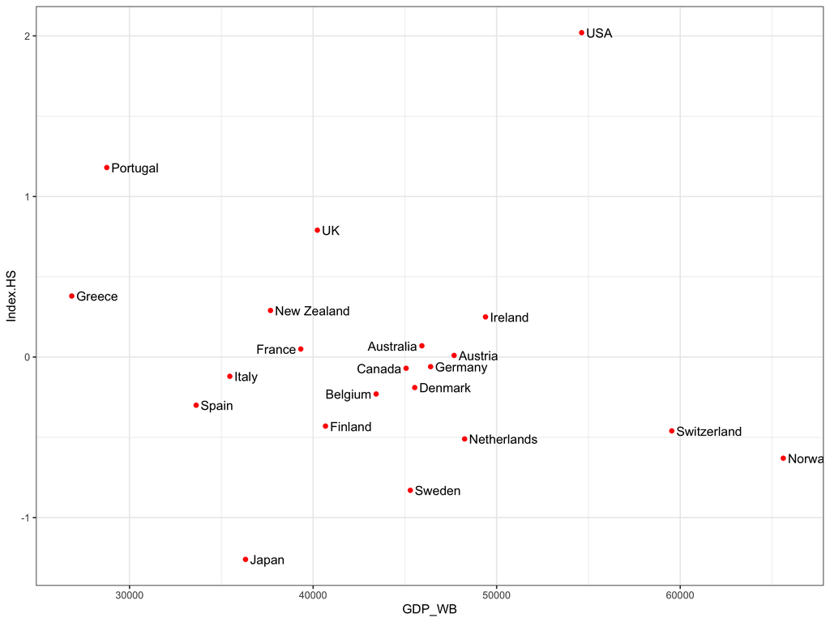

```r
gd4 <- gd2 +
  geom_text(hjust = hjust.text.2,
            nudge_x = nudge_x.text.2)
gd4
```

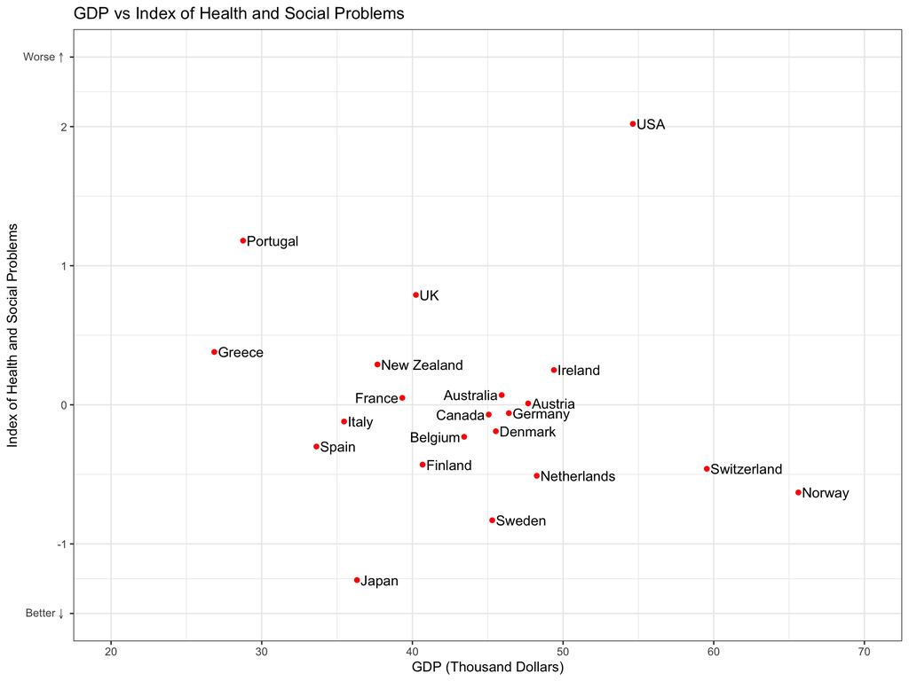

```r
main.title.2 <- "GDP vs Index of Health and Social Problems"
x.lab.2 <- "GDP (Thousand Dollars)"
y.lab.2 <- "Index of Health and Social Problems"
gd5 <- gd4 +
  scale_x_continuous(name = x.lab.2,
                     breaks = seq(20000, 70000, by = 10000),
                     labels = seq(20, 70, by = 10),
                     limits = c(20000, 70000)) +
  scale_y_continuous(name = y.lab.2,
                     breaks = c(-1.5, -1:2, 2.5),
                     labels = c(expression("Better" %down% ""),
                                -1:2,
                                expression("Worse" %up% "")),
                     limits = c(-1.5, 2.5)) +
  labs(title = main.title.2)
gd5
```

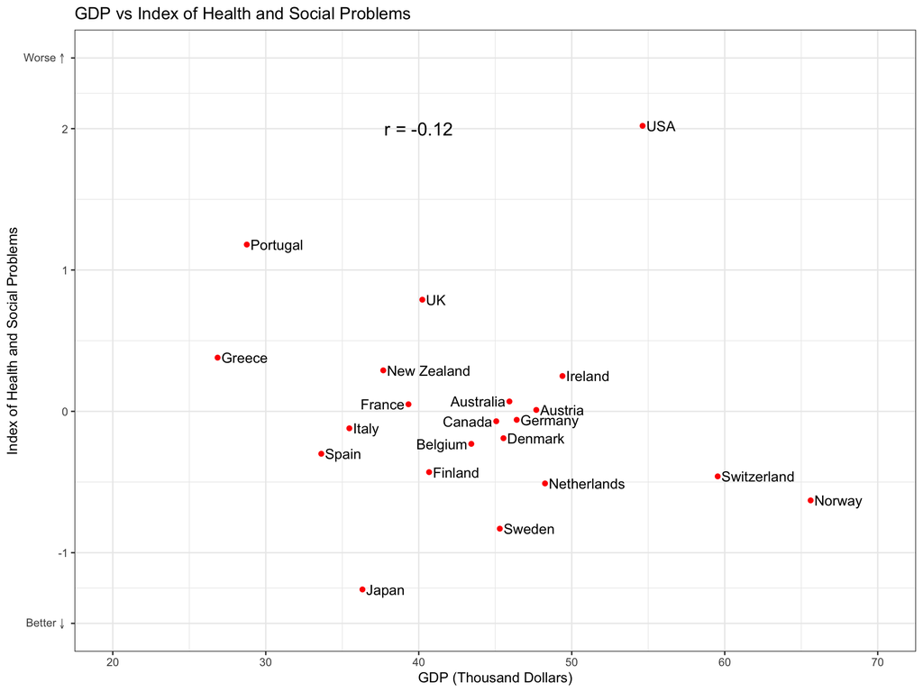

```r
gd6 <- gd5 +
  annotate("text",
           x = 40000,
           y = 2,
           label = paste("r =", round(cor.2, digits = 2)),
           size = 5)
gd6
```

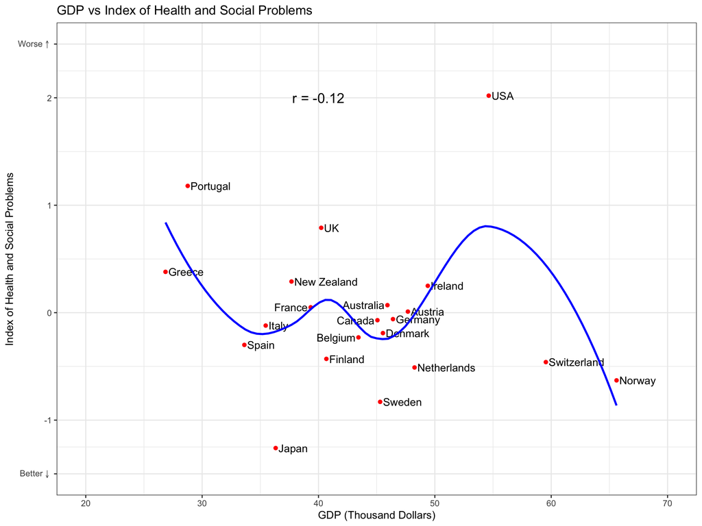

```r
gd7 <- gd6 +
  geom_smooth(colour = "blue",
              se = FALSE,
              inherit.aes = FALSE,
              mapping = aes(x = GDP_WB, y = Index.HS))
gd7
```